# Analisis inteligente de datos TP 1- PUNTOS 3 y 4

```r
#deshabilitar la notacion cientifica
options(scipen=999)
#limpio memoria
rm(list=ls())
gc()
```

```
##          used (Mb) gc trigger (Mb) max used (Mb)
## Ncells 441666 23.6     942432 50.4   638940 34.2
## Vcells 791771  6.1    8388608 64.0  1633606 12.5
```

```r
#cargo librerias
library(tidyverse)
library(dplyr)
library(readr)
library(data.table)
```

```r
library(ggplot2)
library(plotly)
library(summarytools)
setwd("C:/Cursos/mcd/austral-mcd-aid/TP1")

getwd()
```

```
## [1] "C:/Cursos/mcd/austral-mcd-aid/TP1"
```

PUNTO 3- Estadisticas descriptivas y graficos. Leemos la rable resultante del punto

```r
Clientes_Mar21 <- read_csv("C:/Cursos/mcd/datasets/AID/TP1/Clientes_Mar21.csv")
#casteo la columna CLTecno a factor.
Clientes_Mar21$CL_TECNO <- as.factor(Clientes_Mar21$CL_TECNO)
Clientes_Mar21$BASE_STAT_03 <- as.factor(Clientes_Mar21$BASE_STAT_03)

head(Clientes_Mar21)
```

| ACCS_MTHD_CD | BASE_STAT_03 | MONTO_TOTAL | MONTO_TECNO | POR_TECNO_M | CANT_RECARGAS | CANT_RTEC | POR_TECNO | CL_TECNO |
| --- | --- | --- | --- | --- | --- | --- | --- | --- |
| 120008596 | ACTIVE BASE | 31 | 0 | 0.00 | 7 | 0 | 0.00 | 4-No Tecno |
| 120009284 | ACTIVE BASE | 11 | 0 | 0.00 | 3 | 0 | 0.00 | 4-No Tecno |
| 120009978 | ACTIVE BASE | 70 | 70 | 100.00 | 7 | 7 | 100.00 | 1-Tecno |
| 120010448 | ACTIVE BASE | 13 | 10 | 76.92 | 3 | 2 | 66.67 | 2-Mix4070 |
| 120011608 | REJOINNER | 0 | 0 | 0.00 | 0 | 0 | 0.00 | 99-NOSEGM |
| 120012796 | ACTIVE BASE | 0 | 0 | 0.00 | 0 | 0 | 0.00 | 99-NOSEGM |

Realizamos un resumen estadistico del dataframe

```r
summary(Clientes_Mar21)
```

```
##   ACCS_MTHD_CD            BASE_STAT_03      MONTO_TOTAL       MONTO_TECNO
##  Min.   :120008596   ACTIVE BASE:1226943   Min.   :   0.00   Min.   :  0.000
##  1st Qu.:131040072   REJOINNER  :  45890   1st Qu.:   5.00   1st Qu.:  0.000
##  Median :134625010                         Median :  17.00   Median :  0.000
##  Mean   :134106292                         Mean   :  25.93   Mean   :  4.968
##  3rd Qu.:136816224                         3rd Qu.:  44.00   3rd Qu.:  3.000
##  Max.   :139988818                         Max.   :1140.00   Max.   :845.000
##   POR_TECNO_M     CANT_RECARGAS       CANT_RTEC        POR_TECNO
##  Min.   :  0.00   Min.   :  0.000   Min.   :  0.00   Min.   :  0.00
##  1st Qu.:  0.00   1st Qu.:  1.000   1st Qu.:  0.00   1st Qu.:  0.00
##  Median :  0.00   Median :  4.000   Median :  0.00   Median :  0.00
##  Mean   : 15.11   Mean   :  5.904   Mean   :  1.02   Mean   : 15.03
##  3rd Qu.:  7.89   3rd Qu.: 10.000   3rd Qu.:  1.00   3rd Qu.:  8.33
##  Max.   :100.00   Max.   :226.000   Max.   :136.00   Max.   :100.00
##        CL_TECNO
##  1-Tecno   : 88107
##  2-Mix4070 : 50771
##  3-MixH40  :136088
##  4-No Tecno:508421
##  99-NOSEGM :489446
##
```

Del resumen estadistico, podemos notar:

```r
freq(Clientes_Mar21$BASE_STAT_03, plain.ascii = FALSE, style = "rmarkdown")
```

```
## ### Frequencies
## #### Clientes_Mar21$BASE_STAT_03
## **Type:** Factor
##
## |          &nbsp; |    Freq | % Valid | % Valid Cum. | % Total | % Total Cum. |
## |----------------:|--------:|--------:|-------------:|--------:|-------------:|
## | **ACTIVE BASE** | 1226943 |   96.39 |        96.39 |   96.39 |        96.39 |
## |   **REJOINNER** |   45890 |    3.61 |       100.00 |    3.61 |       100.00 |
## |      **\<NA\>** |       0 |         |              |    0.00 |       100.00 |
## |       **Total** | 1272833 |  100.00 |       100.00 |  100.00 |       100.00 |
```

```r
freq(Clientes_Mar21$CL_TECNO, plain.ascii = FALSE, style = "rmarkdown")
```

```
## ### Frequencies
## #### Clientes_Mar21$CL_TECNO
## **Type:** Factor
##
## |         &nbsp; |    Freq | % Valid | % Valid Cum. | % Total | % Total Cum. |
## |---------------:|--------:|--------:|-------------:|--------:|-------------:|
## |    **1-Tecno** |   88107 |    6.92 |         6.92 |    6.92 |         6.92 |
## |  **2-Mix4070** |   50771 |    3.99 |        10.91 |    3.99 |        10.91 |
## |   **3-MixH40** |  136088 |   10.69 |        21.60 |   10.69 |        21.60 |
## | **4-No Tecno** |  508421 |   39.94 |        61.55 |   39.94 |        61.55 |
## |  **99-NOSEGM** |  489446 |   38.45 |       100.00 |   38.45 |       100.00 |
## |     **\<NA\>** |       0 |         |              |    0.00 |       100.00 |
## |      **Total** | 1272833 |  100.00 |       100.00 |  100.00 |       100.00 |
```

De las frecuencias podemos inferir:

-Vemos una marcada mayoria de clientes ACTIVE BASE con mas del 96% sobre los clientes REJOINER

```r
#Cantidad de clientes por segmento y grupo
aux_data<-Clientes_Mar21 %>% group_by(CL_TECNO,BASE_STAT_03) %>%
          summarise(cant = n())
```

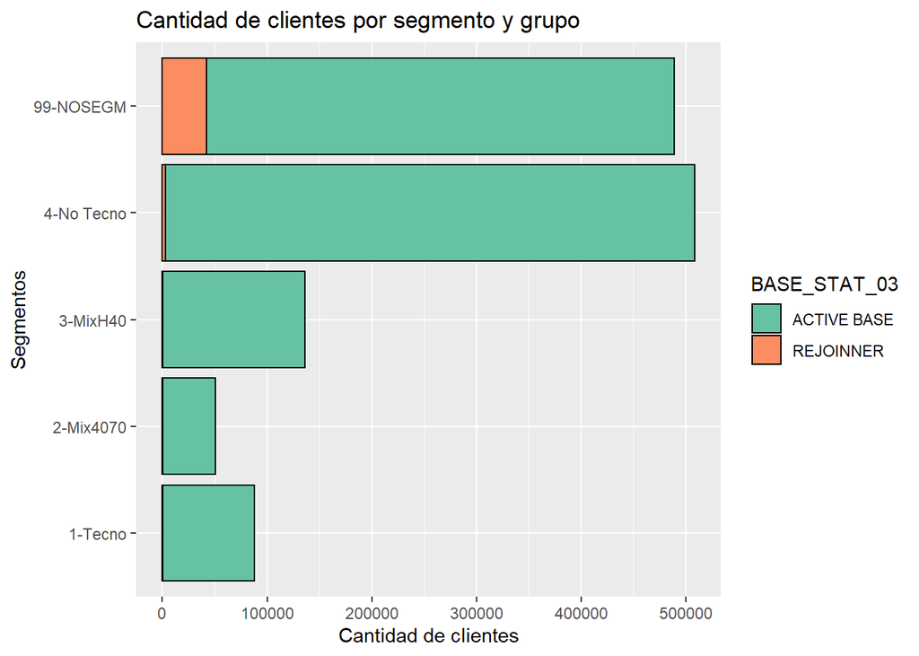

```r
ggplot(aux_data, aes(x=CL_TECNO,y=cant, fill=BASE_STAT_03))+
  geom_bar(stat="identity",color='black')+
  scale_fill_brewer(palette='Set2')+
  coord_flip()+
  labs(x="Segmentos",  y="Cantidad de clientes")+
  ggtitle("Cantidad de clientes por segmento y grupo")
```

-Del grafico anterior podemos notar que la mayoria de los clientes REJOINER realizaron menos de TRES recargas en los ultimos tres meses. Sin embargo, para el resto de los segmentos, es notable la mayoria de los clientes ACTIVE BASE

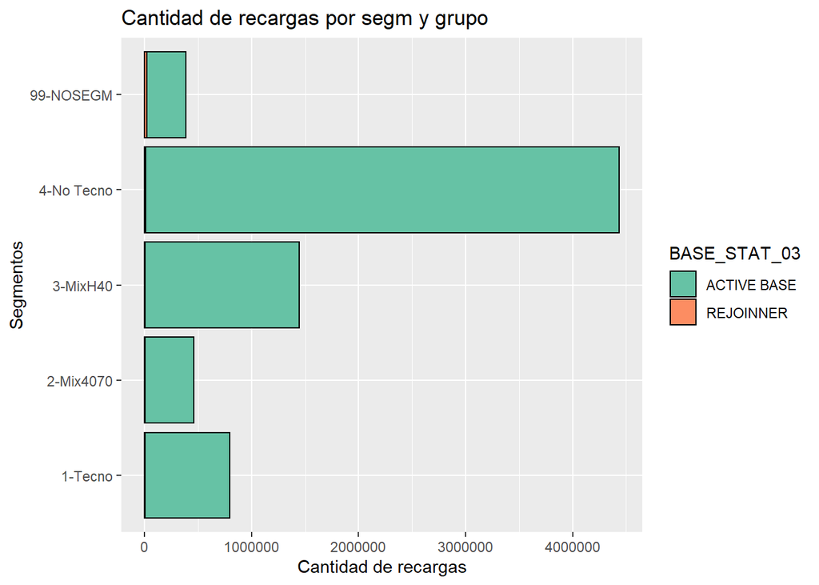

```r
#Cantidad de recargas por segm y grupo
aux2 <- aggregate(CANT_RECARGAS ~ CL_TECNO + BASE_STAT_03, data = Clientes_Mar21, FUN = sum)
ggplot(aux2, aes(x=CL_TECNO,y=CANT_RECARGAS, fill=BASE_STAT_03))+
  geom_bar(stat="identity",color='black')+
  scale_fill_brewer(palette='Set2')+
  coord_flip()+
  labs(x="Segmentos",  y="Cantidad de recargas")+
  ggtitle("Cantidad de recargas por segm y grupo")
```

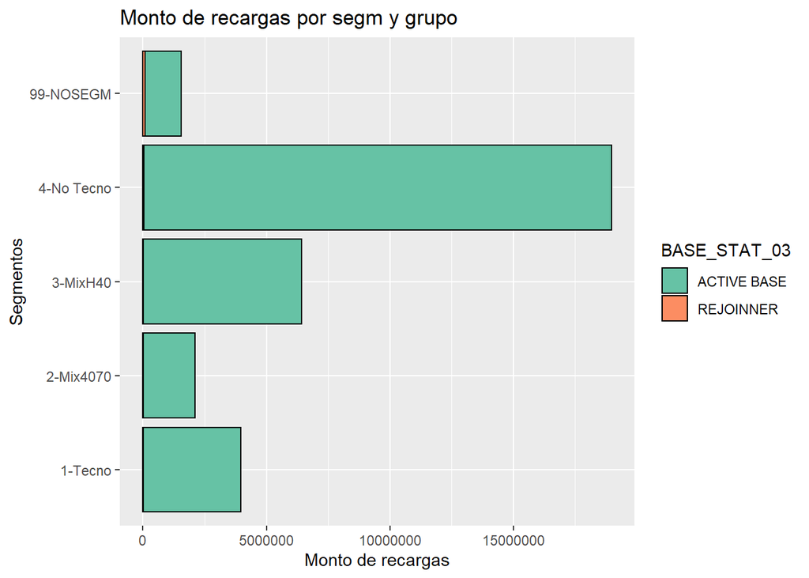

```r
#Monto de recargas por segmento y grupo
aux3 <- aggregate(MONTO_TOTAL ~ CL_TECNO + BASE_STAT_03, data = Clientes_Mar21, FUN = sum)
ggplot(aux3, aes(x=CL_TECNO,y=MONTO_TOTAL, fill=BASE_STAT_03))+
  geom_bar(stat="identity",color='black')+
  scale_fill_brewer(palette='Set2')+
  coord_flip()+
  labs(x="Segmentos",  y="Monto de recargas")+
  ggtitle("Monto de recargas por segm y grupo")
```

Respecto al MONTO y la CANTIDAD de recargas por segmento y grupo.

-vemos una fuerte relacion entre estas variables, practicamente los graficos tienen una distribucion similar.

-Tambien podemos ver que el semento dominante tanto en cantidad y en monto es 4-No Tecno, es decir, que los clientes siguen prefiriendo la recarga manual

*POR UN TEMA DE RENDIMINETO* para los siguientes graficos tomo una muestra de 10000 registros

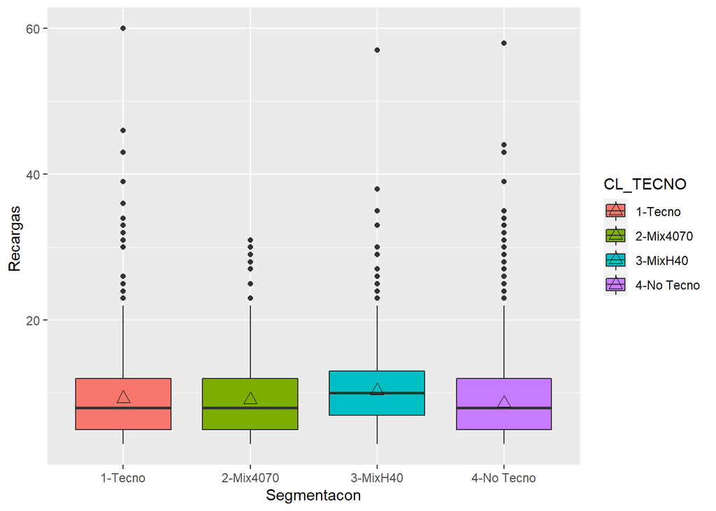

```r
#TOMO UNA MUESTRA RANDOM DE n=10000 para agilizar los graficos
n <- 10000
cli_sample <- Clientes_Mar21[sample(nrow(Clientes_Mar21),n,replace = FALSE),]

ggplot(filter(cli_sample, CL_TECNO!='99-NOSEGM'), aes(x=CL_TECNO, y=CANT_RECARGAS, fill = CL_TECNO)) +
  geom_boxplot()+
  stat_summary(fun=mean, geom="point", shape=2, size=3)+
  labs(x="Segmentacon",  y="Recargas ",color="Tipo")
```

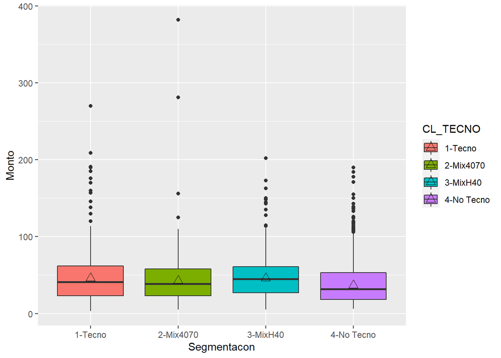

```r
ggplot(filter(cli_sample, CL_TECNO!='99-NOSEGM'), aes(x=CL_TECNO, y=MONTO_TOTAL, fill = CL_TECNO)) +
  geom_boxplot()+
  stat_summary(fun=mean, geom="point", shape=2, size=3)+
  labs(x="Segmentacon",  y="Monto",color="Tipo")
```

En los graficos de box plot, tanto para MONTO y CANTIDAD

-Notamos gran cantidad de valores atipicos (outliers), mas alla de los casos extremos leves

-vemos tambien una gran similitud en la dispersion de los segmentos 1,2 y 4

-La mediana es muy similar en los segmentos 1 y 2

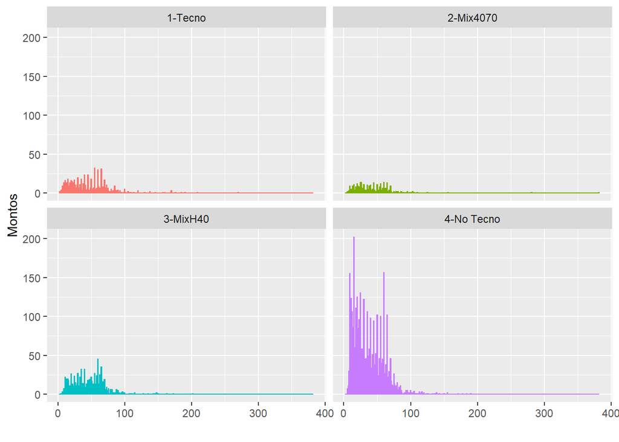

```r
# MONTO por segmento
cli_sample%>%filter( CL_TECNO!='99-NOSEGM' ) %>%
  ggplot(aes(x=MONTO_TOTAL,fill=CL_TECNO,color=CL_TECNO))+
  facet_wrap(~CL_TECNO) +
  geom_histogram( binwidth=1,show.legend=FALSE, alpha=0.9)+
  labs(y = "Montos",x = "")
```

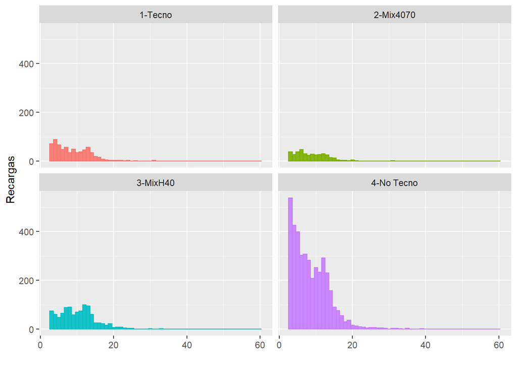

```r
# RECARGAS por segmento
cli_sample%>%filter( CL_TECNO!='99-NOSEGM' ) %>%
  ggplot(aes(x=CANT_RECARGAS,fill=CL_TECNO,color=CL_TECNO))+
  facet_wrap(~CL_TECNO) +
  geom_histogram( binwidth=1,show.legend=FALSE, alpha=0.9)+
  labs(y = "Recargas",x = "")
```

Como conclusión sobre el comportamiento de los segmentos, respecto al monto y a la cantidad de recargas. Podríamos decir:

1. Más allá del segmento que se estudie, una marcada relación entre las variables MONTO_TOTAL y CANT_RECARGAS
2. EL 21.6% de los clientes el canal tecnológico para realizar recargas, está lejos del 40% de clientes que no lo uso nunca, lo cual podría ser una dificultad a la hora de plantear una migración.
3. En los meses estudiados, el segmento predominante, tanto en recargas como en monto, fue el “4-No Tecno”. Esto nos dice que casi el 40% de los clientes NO UTILIZA canales de recargas tecnológicos.
4. Hay un 38.5% de clientes ACTIVE BASE o REJOINER que no realizaron cargas significativas (menos de 3) en los meses estudiados.